www.economicsofmalaria.com joebrew@gmail.com

# Maragra and Malaria: preliminary analysis

This document contains some basic preliminary analysis of data relating to malaria, IRS, and absenteeism at Maragra Açucar, in Maragra, Mozambique. To explore a specific section, click any of the below tabs.

## Description of data

The “Maragra database” consists of the following 6 tables:

| Table name | Number or rows | Number of columns |
| --- | --- | --- |
| ab | 83191 | 12 |
| ab_panel | 1964856 | 6 |
| clinic | 3403 | 9 |
| clinic_agg | 138 | 8 |
| mc | 11576 | 13 |
| workers | 14195 | 22 |

These tables all constitute three kinds of data: those pertaining to medical outcomes (generally referred to as “clinic” data), those pertaining to worker information (demographic and absenteeism-related), and those pertaining to malaria control activities.

These datasets are all readily available in the (private) `maragra` R package (access credentials given to collaborators upon joebrew@gmail.com). All datasets except for `ab_panel` are *as is* (ie, in their original raw format), except for 4 kinds of changes:

1. Removal of unecessary information (columns deemed irrelevant to the study have been removed).
2. Modification of column names (all data now employ underscores instead of spaces, and are all lowercase).
3. Standardization of data formats (all dates are now in a YYYY-MM-DD format, all names use similar capitalization, irrelevant tablet-created timestamps, etc. have been removed).
4. “Feature generation”: certain columns were created in order to ease grouped analysis and merging of datasets (for example, `year_month`, `day_number`, etc.).

The `ab_panel` dataset is *not* raw data; rather, it is an amolgamation of the `ab` and `workers` datasets, using absence data from the former with worker elibility dates from the latter, so as to create a “panel” style dataset (ie, one row for each day in which a worker was *supposed* to work).

For a “deep dive” into each kind of data, click the tabs at the top of this page.

In order to reproduce this analysis (and others related to these datasets), follow the instructions on this project’s [research compendium page](https://github.com/joebrew/maragra#purpose).

## IRS analysis

### Data structure

Data about “fumigações” (indoor residual spraying or “IRS”) dates from 2011-10-30 through 2017-07-23. The dataset consists of the following fields:

```
date
insecticida
casas_cobertas
pulverizados
meta_instance_name
unidade
casas_total
month
year
dow
day
day_number
year_month
```

Each row is one fumigation activity. The location/residence key is the `unidade` column. The `casas_cobertas` column indicates the number of houses in that `unidade` that were sprayed, wereas the `pulverizados` column indicates the number of rooms.

### Insecticide type

The insecticide used is either DDT or ACT. The below is a breakdown of their respective use.

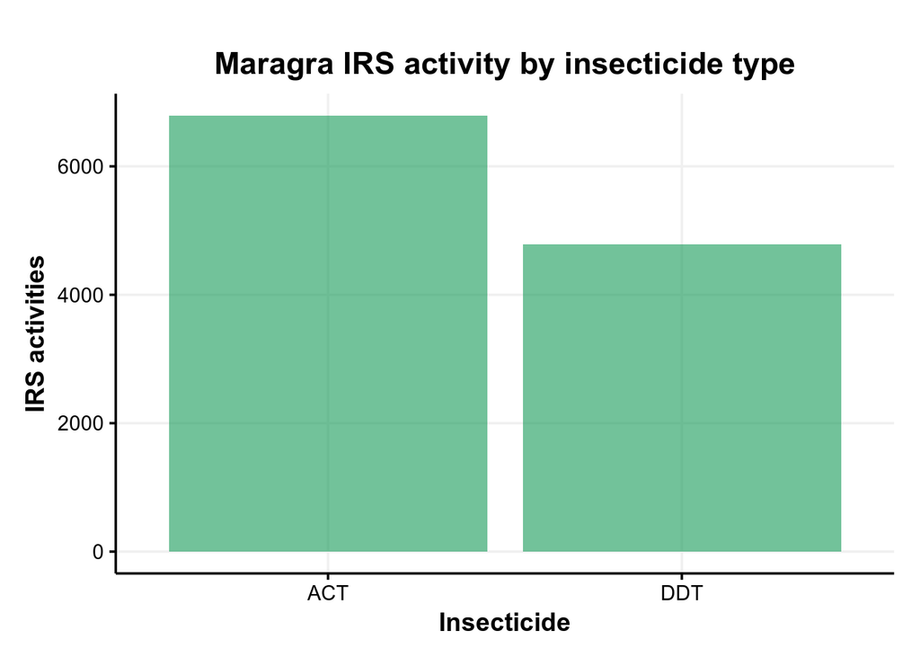

The respective use over time is as follows:

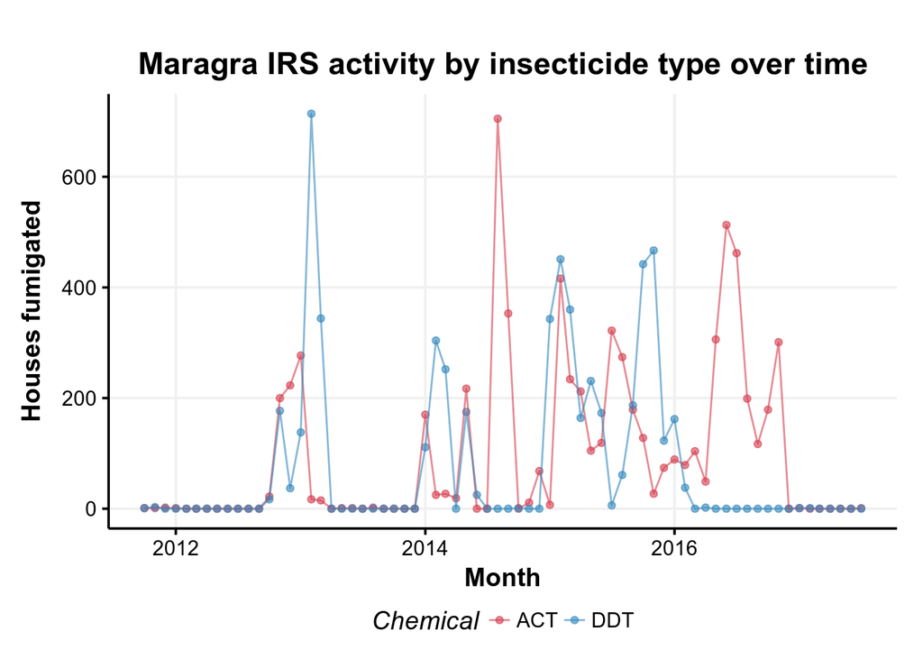

Below is a table of the same data.

|  | Date | Insecticida | Houses |
| --- | --- | --- | --- |
| 1 | 2011-10-01 | ACT | 1 |
| 2 | 2011-11-01 | ACT | 1 |
| 3 | 2011-12-01 | ACT | 2 |
| 4 | 2012-01-01 | ACT | 1 |
| 5 | 2012-02-01 | ACT | 0 |
| 6 | 2012-03-01 | ACT | 0 |
| 7 | 2012-04-01 | ACT | 0 |
| 8 | 2012-05-01 | ACT | 0 |
| 9 | 2012-06-01 | ACT | 0 |
| 10 | 2012-07-01 | ACT | 0 |

[output cut: 130 more lines]

### IRS seasonality

We can examine the date of fumigations to see if they are seasonal vs. randomly/uniformly distributed throughout the year.

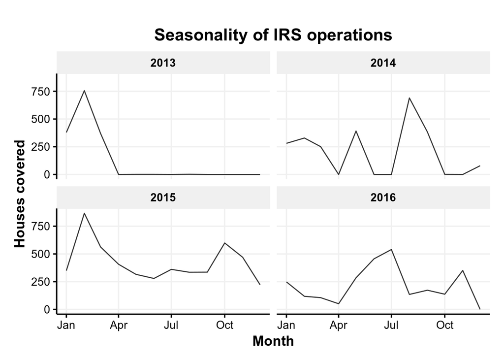

## Absenteeism analysis

### Data structure

The analysis of absenteeism data will rely on a panel-style dataset in which one row exists for each worker-day (for which the worker is estimated to have *supposed to work*), with columns indicating the outcome (absent or not, sick or not, etc.). The Maragra CRM does not natively store panel style data, so we construct it from a combination of the `workers` dataset (from the Human Resources department) and the `absenteeism` dataset. Certain features pertaining to illness are merged from the `clinic` dataset.

The `ab_panel` dataset has the following column names:

```
oracle_number
date
leave_type
leave_taken
absent
absent_sick
```

### Data magnitude

Overall, we have observed 1964856 eligible worker days (the equivalent of 5379 years of human activity!), from the period of 2013-01-01 through 2017-03-31.

### Absenteeism

Our dataset includes 101188 absences and 1863668 presences, which can be broken down below in percentage terms.

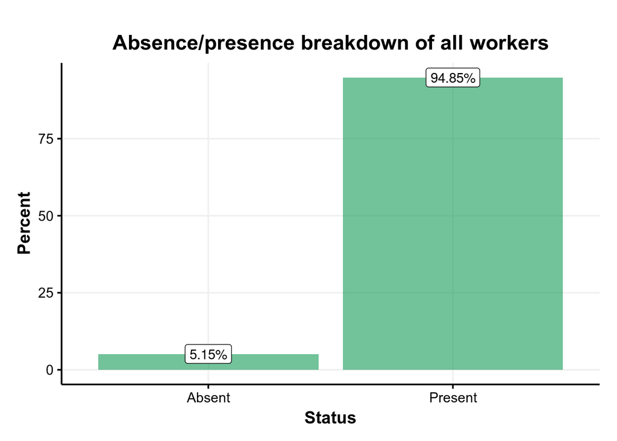

Among absences, the breakdown of absence “type” is as follows.

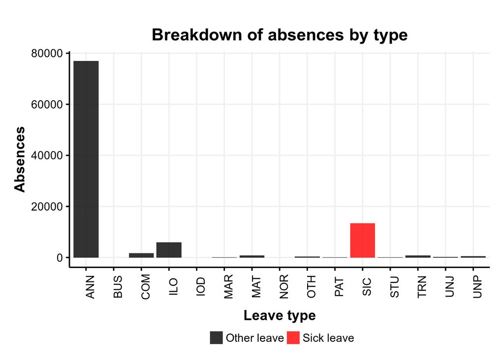

### Absenteeism rate

We calculate an absenteeism rate for any given time period (day, month, etc.) as the number of days not worked divided by the number of days which *should have* been worked, and multiplied by 100. The below shows the absenteeism rate, by day, for the entire observation period. The size of each dot is a reflection of the number of workers observed at that time.

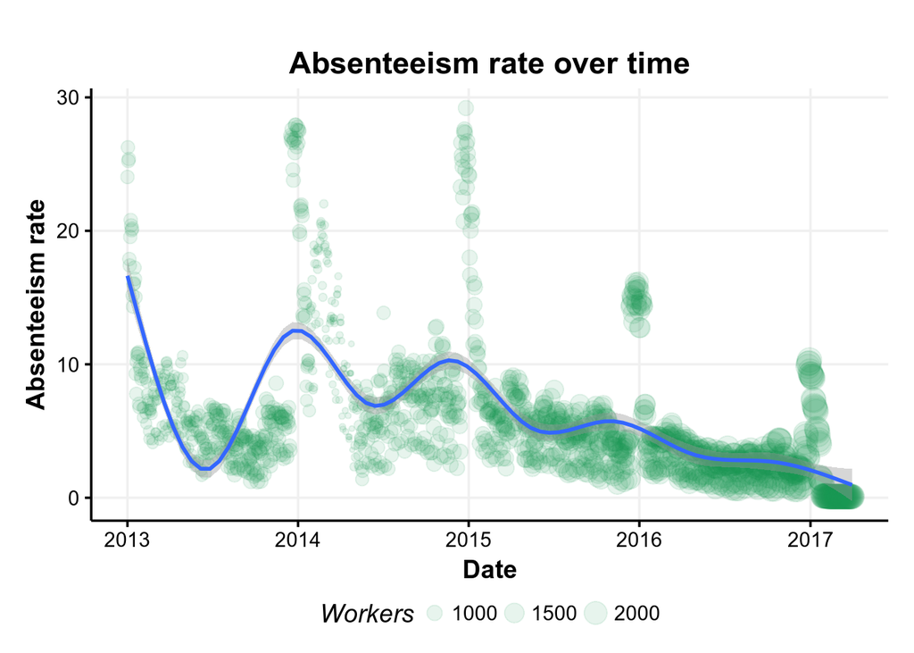

### Sick absenteeism rate

We again calculate the absenteeism rate, but only for those who absences which are classified as “sick leave”.

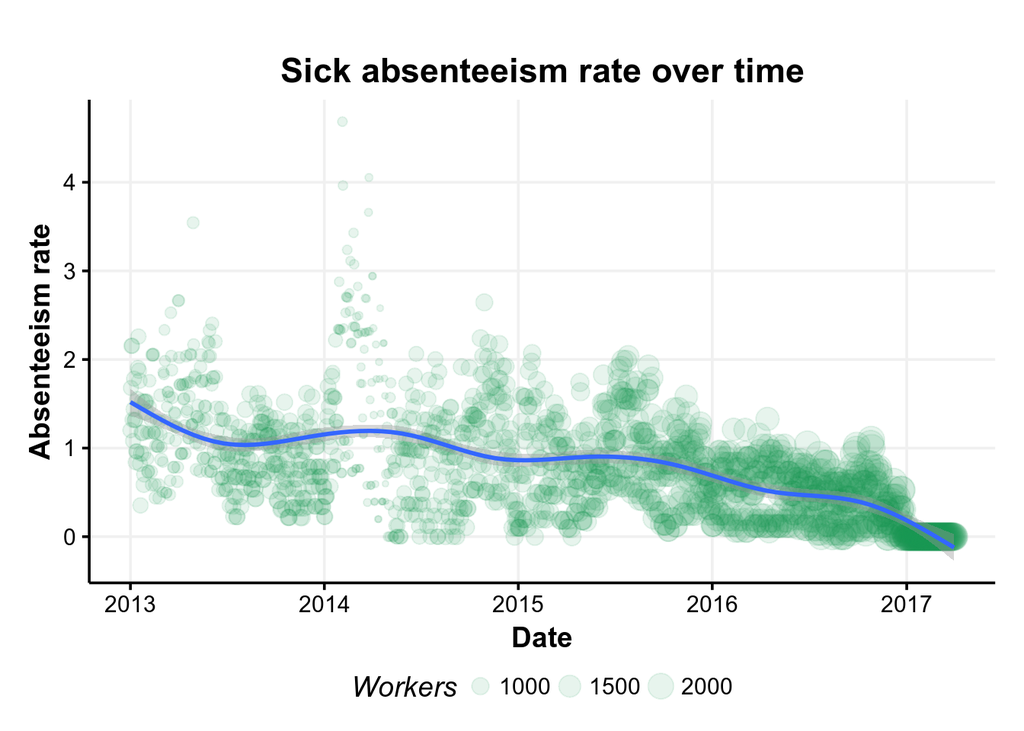

### Monthly absenteeism

Daily absenteeism is problematic in that it introduces a great deal of noise. So, we examine monthly absenteeism rates for both all and sick absences. The below chart shows these metrics, as well as the percentage of monthly absences due to sickness, and the number of worker-days observed. A local regression smoothed line is overlaid to see overall trends.

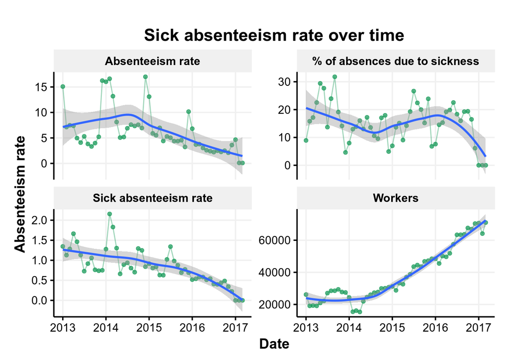

### Absenteeism by worker type

The below chart is a paneling of (a) type of absenteeism metric (columns) and (b) type of worker (rows).

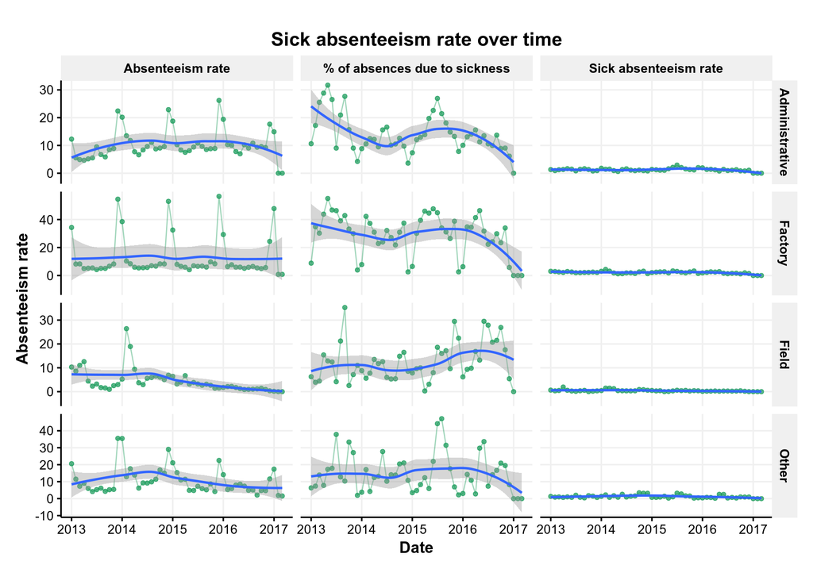

## Clinic analysis

### Data structure

The `clinic` dataset has the following fields:

```
date
name
severity
month
year
dow
day
day_number
year_month
```

The `clinic_agg` dataset has the following fields:

```
month
year
group
tested
positive
negative
date
percent_positive
```

### Cases over time - from `clinic_agg`

#### All workers

If we combine all workers, we can examine the total incidence of malaria since 2011.

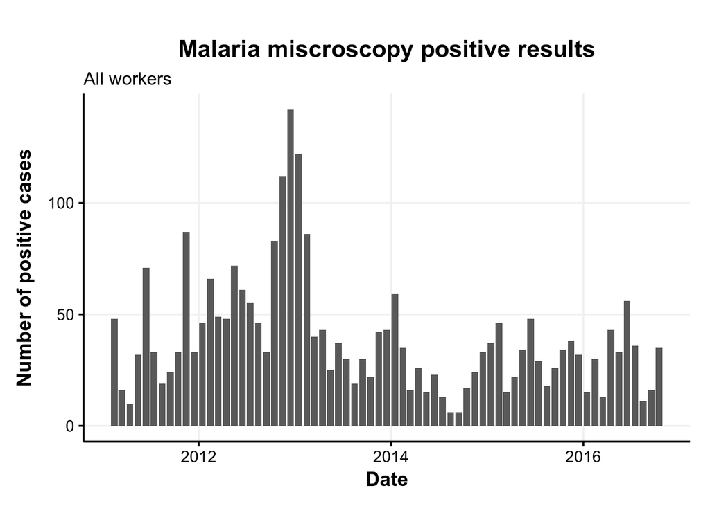

### Cases and tests from `clinic_agg`

#### Absolute numbers

The below chart shows both the number of positive cases (all workers, in red) and the number of tests, by month.

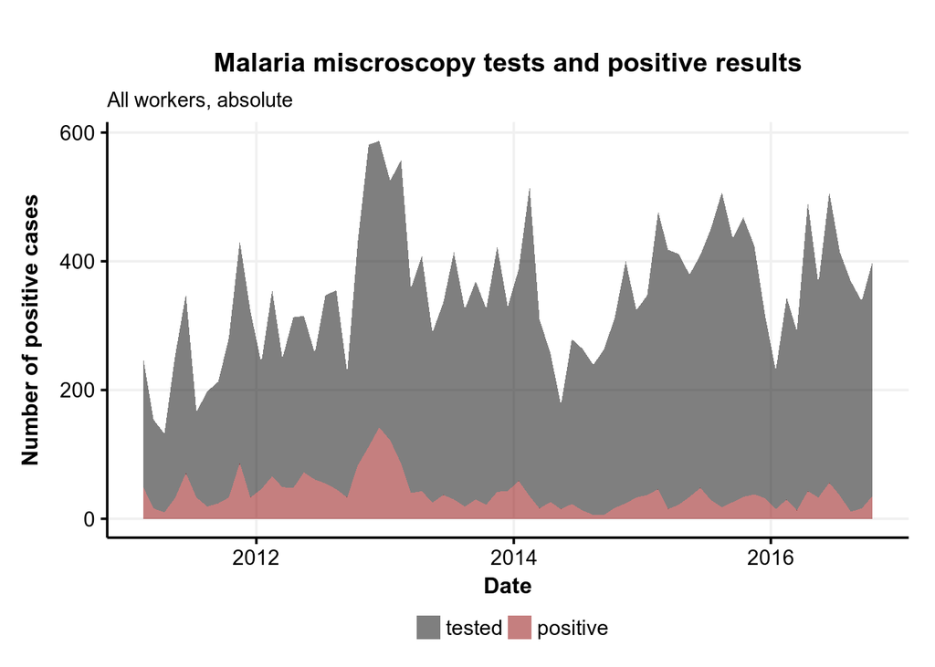

#### Relative numbers

The below chart shows the same data as above, but convers the number of positive cases to a percentage of all tests, rather than an absolute number.

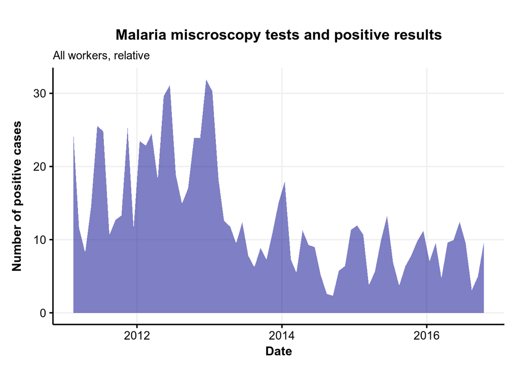

### Seasonality analysis from `clinic_agg`

We can examine the annual seasonality of positive cases by overlaying all years’ data onto one axis.

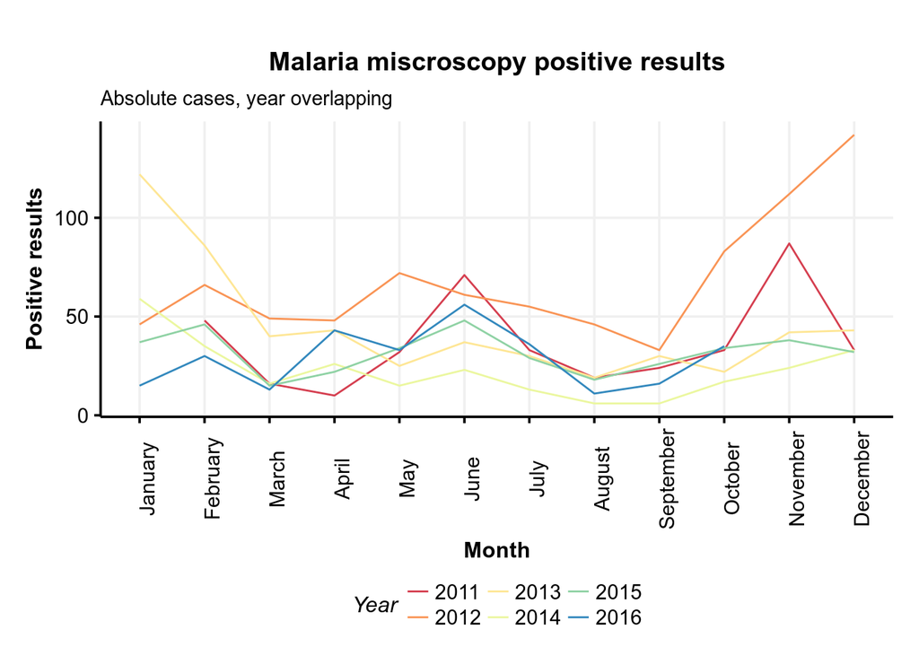

[figure not shown]

If we aggregate and view distributions (via “violin” charts) at the level of the month, seasonality is more apparent.

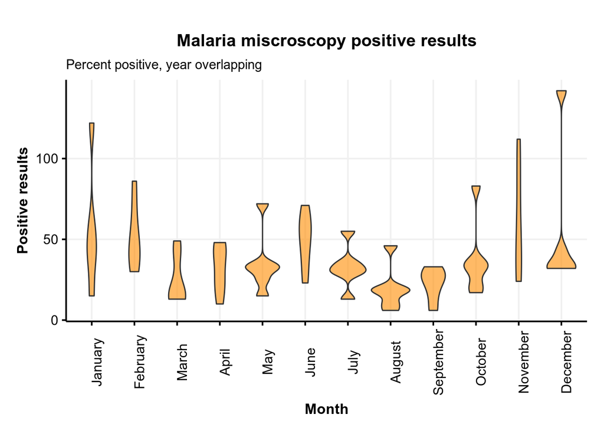

### Malaria severity distribution from `clinic`

The below chart shows the severity of all clinical malaria cases in the Maragra clinic.

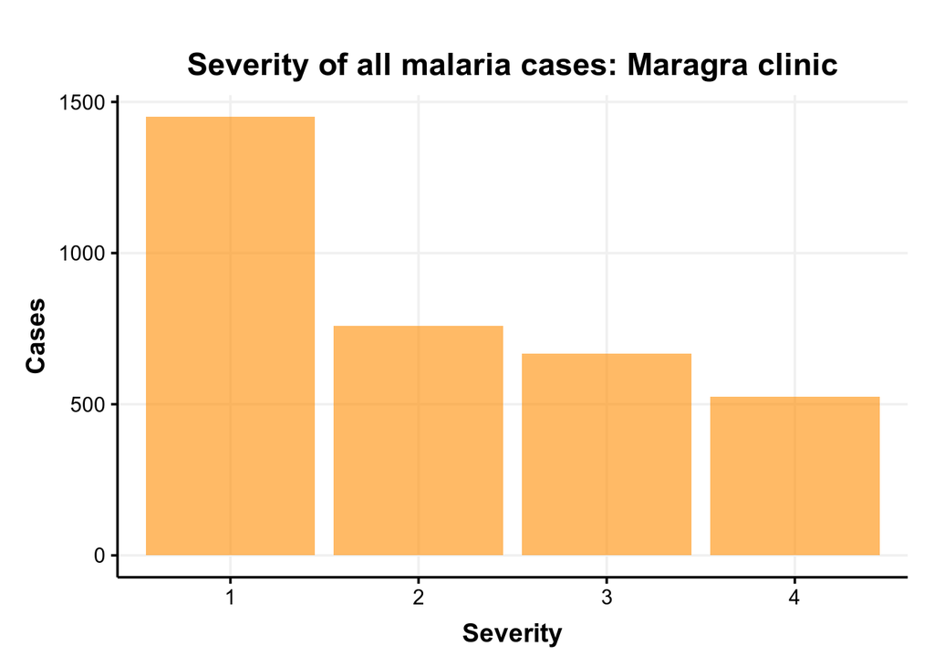

The below chart shows severity, but over time.

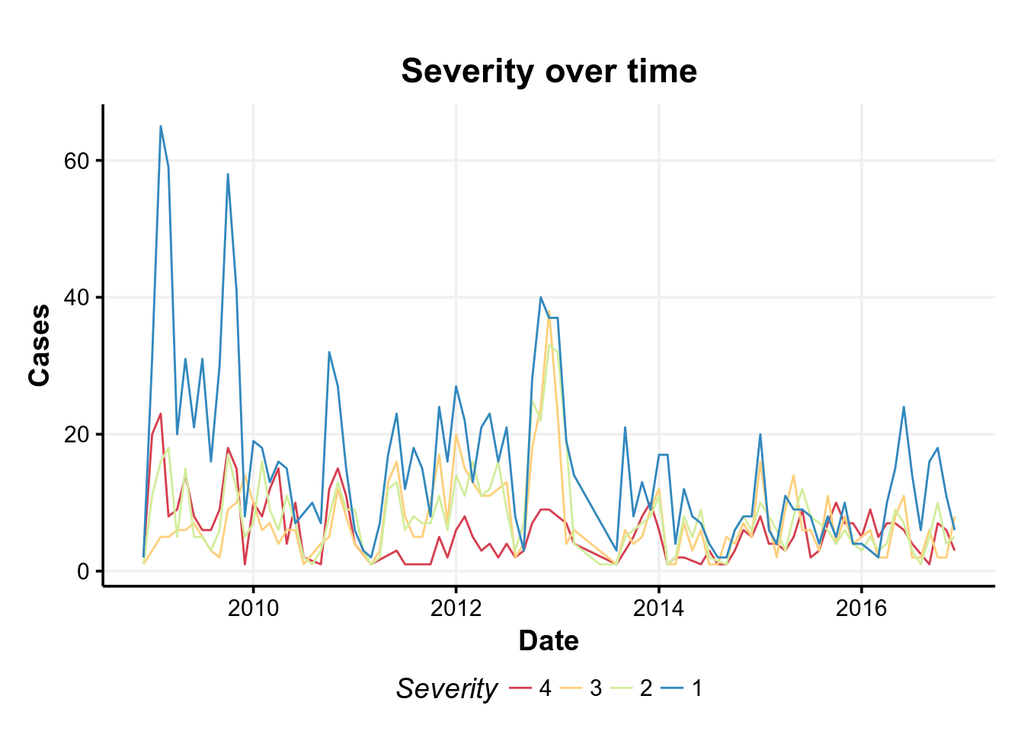

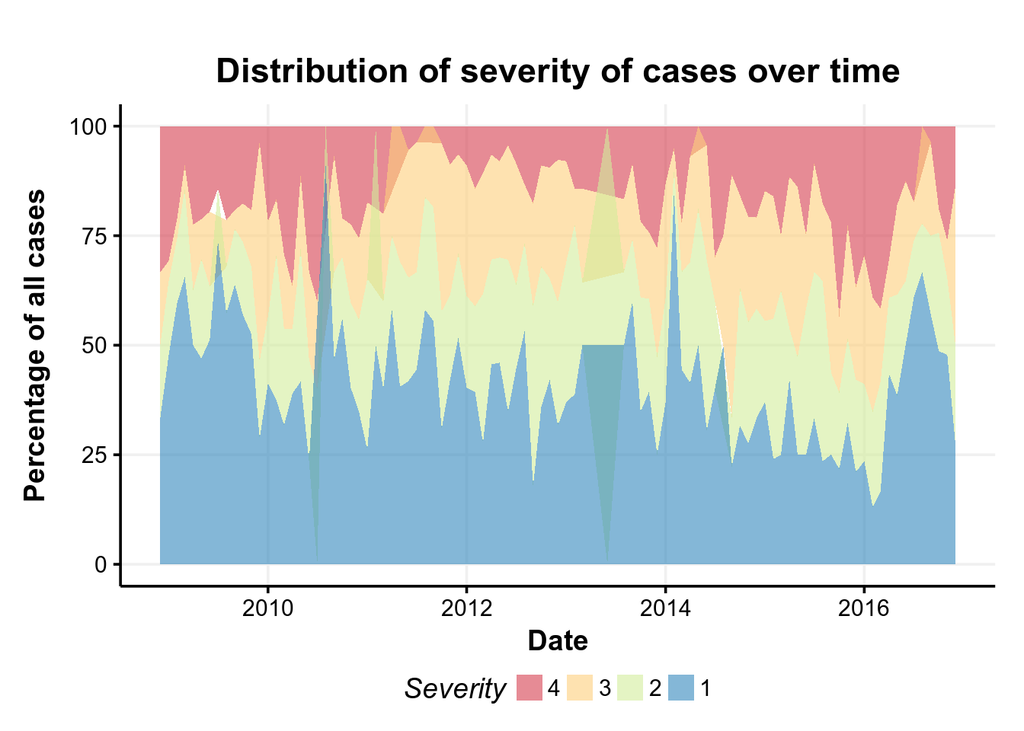

## Next steps

A lot of work remains to be done:

- Figure out how to transform the `unidade` codes from the IRS data to specific workers’s residences (or at least geographical area).
- Perform some name standardization so as to better link individual level clinical data with workers demographic and absenteeism data.
- Join data with census data for more demographic analysis, particularly in terms of absenteeism and health.
- Estimate a model for absenteeism, adjusting for relevant factors, particularly the IRS status and time since IRS.
- A cost-effectiveness framework for estimating the return on investment for IRS activities.